# Assignment 6 - Data Exploration and Confidence Intervals

**Created by John Palowitch, UNC Chapel Hill**

**Edited - Robin Cunningham**

1. In this problem you will practice plotting density curves in **R**. (I saved you the trouble of a possible Google Search, by searching myself and finding this page: [Robin’s Google Search Result](http://www.statmethods.net/advgraphs/probability.html) You may find the first gray box of code on this page very helpful. This is how a lot of the world’s coding is done!)
   1. Plot the *Standard* Normal density curve on the range [-4, 4]. Label your axes, and title the plot “Comparing t and Standard Normal densities”.
   2. Overlay the density of two $t$-distributions: one with 5 degrees of freedom, and the other with 10 degrees of freedom. Color one $t$-curve blue and the other red.
   3. Comment on the plot. What does it suggest happens to the $t$-distribution as degrees of freedom increase? Why does this make sense, considering how and why we use the $t$-distribution?

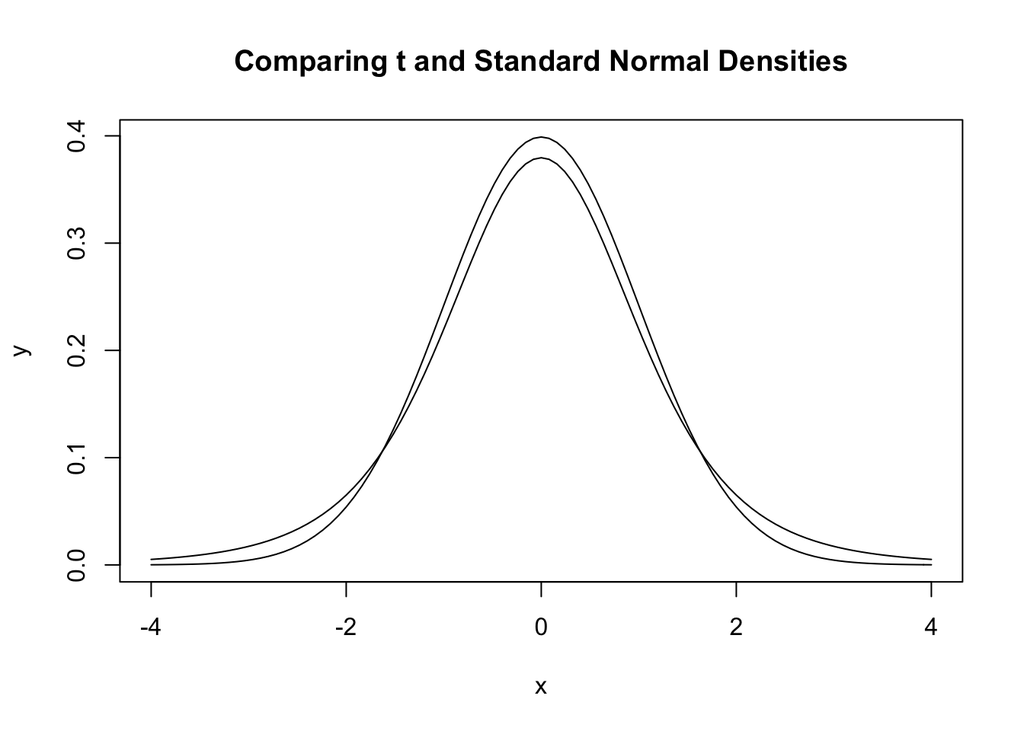

```
Your comments and answers here.
It approaches zero more slowly
```

```r
curve(dnorm(x, mean=0, sd=1), to=4, from=-4, add=FALSE, xlab="x", ylab="y", main="Comparing t and Standard Normal Densities")
curve(dt(x, df=5), to = 4, from = -4,  add= TRUE)
```

2. A code line is provided to load the marathon data set into your **R** workspace. Check your work by printing the `head` of the data frame and seeing that it matches with the commented lines provided.

```r
# Load the data
runner_data <- read.table("rocknroll_marathon_mf2015.txt", header = TRUE)
head(runner_data)
```

```
##   ID Gender Time.Format Place Time.Seconds     MPH
## 1  1      1     5:49:48  2475        20988 4.49721
## 2  2      1     5:19:25  2232        19165 4.92499
## 3  3      1     4:40:16  1635        16816 5.61296
## 4  4      1     4:15:36  1121        15336 6.15464
## 5  5      1     4:19:16  1204        15556 6.06759
## 6  6      1     5:29:49  2327        19789 4.76970
```

```r
# > head(runner_data)
#   ID Gender Time.Format Place Time.Seconds     MPH
# 1  1      1     5:49:48  2475        20988 4.49721
# 2  2      1     5:19:25  2232        19165 4.92499
# 3  3      1     4:40:16  1635        16816 5.61296
# 4  4      1     4:15:36  1121        15336 6.15464
# 5  5      1     4:19:16  1204        15556 6.06759
# 6  6      1     5:29:49  2327        19789 4.76970
```

3. In this question we’ll do some preliminary checks on the data set.
   1. Write code to make a boxplot of this data. Title it “Full Data”. Be sure to label the appropriate axes.
   2. Are there any clear outliers? If you think there are, write whether or not you would like to remove them, and if so, a possible (real-life) explanation for why this might be justified.
   3. If you identified outliers, remove them from the data set (hint: First select a threshold value and subset the full data set by keeping only times below this threshold.). Then remake the boxplot and title it “Outliers Removed”. (If no outliers, attempt Part (b) again.)

```r
# Answer Number 3 Here
summary(runner_data)
```

```
##        ID             Gender       Time.Format       Place
##  Min.   :   1.0   Min.   :1.000   4:28:25:   6   Min.   :   1.0
##  1st Qu.: 313.0   1st Qu.:1.000   4:35:59:   4   1st Qu.: 625.5
##  Median : 625.0   Median :2.000   5:17:59:   4   Median :1250.0
##  Mean   : 642.0   Mean   :1.582   3:11:44:   3   Mean   :1250.0
##  3rd Qu.: 937.5   3rd Qu.:2.000   3:36:15:   3   3rd Qu.:1874.5
##  Max.   :1454.0   Max.   :2.000   3:45:48:   3   Max.   :2499.0
##                                   (Other):2476
##   Time.Seconds         MPH
##  Min.   :  9451   Min.   :4.278
##  1st Qu.: 13948   1st Qu.:5.383
##  Median : 15705   Median :6.010
##  Mean   : 16526   Mean   :6.126
##  3rd Qu.: 17536   3rd Qu.:6.769
##  Max.   :926510   Max.   :9.987
##                   NA's   :2
```

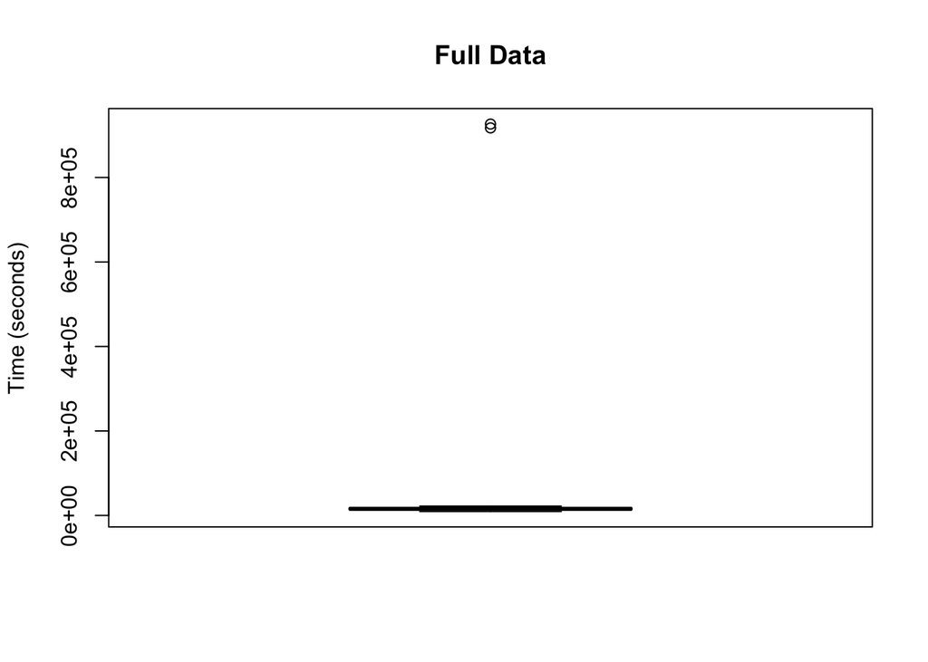

```r
boxplot(runner_data$Time.Seconds, main="Full Data", ylab="Time (seconds)", col="grey")
```

```r
runner_data = runner_data[runner_data$Time.Seconds < 800000,]
summary(runner_data)
```

```
##        ID             Gender       Time.Format       Place
##  Min.   :   1.0   Min.   :1.000   4:28:25:   6   Min.   :   3
##  1st Qu.: 313.0   1st Qu.:1.000   4:35:59:   4   1st Qu.: 627
##  Median : 625.0   Median :2.000   5:17:59:   4   Median :1251
##  Mean   : 641.7   Mean   :1.581   3:11:44:   3   Mean   :1251
##  3rd Qu.: 937.0   3rd Qu.:2.000   3:36:15:   3   3rd Qu.:1875
##  Max.   :1454.0   Max.   :2.000   3:45:48:   3   Max.   :2499
##                                   (Other):2474
##   Time.Seconds        MPH
##  Min.   : 9451   Min.   :4.278
##  1st Qu.:13944   1st Qu.:5.383
##  Median :15704   Median :6.010
##  Mean   :15801   Mean   :6.126
##  3rd Qu.:17535   3rd Qu.:6.769
##  Max.   :22061   Max.   :9.987
##
```

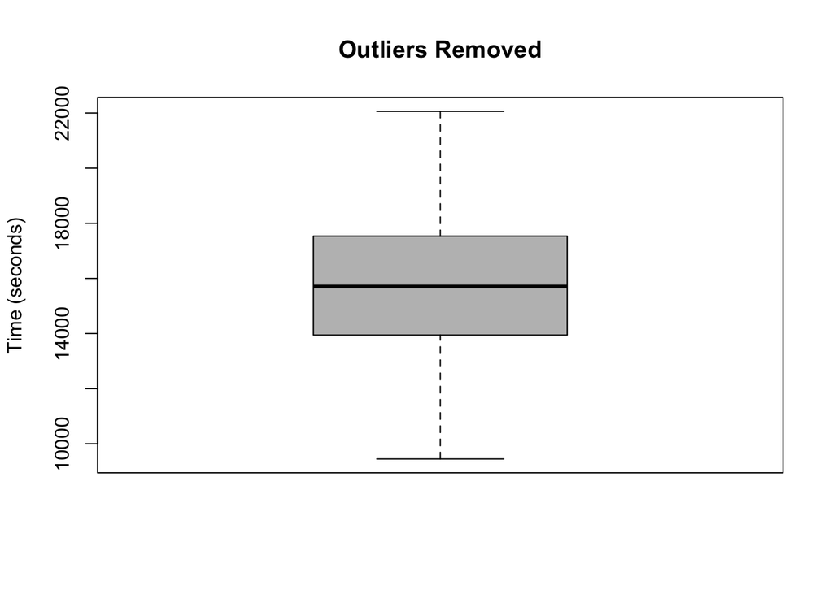

```
Your written answers/comments here.
There are two extreme outliers. I would remove them, as the difference is extreme and could be an error or it could be two people who stopped for a while for whatever reason.
```

```r
boxplot(runner_data$Time.Seconds, main="Outliers Removed", ylab="Time (seconds)", col="grey")
```

4. In this question we’ll explore basic calculations with the Normal distribution, and investigate the Normality of the data set.
   1. Calculate the mean and standard deviation of all runners’ times. Store them in variables called `xbarT` and `sT`, and print them in the output.
   2. Suppose runners’ times were *in truth* Normally distributed with parameters $\bar x$ and $s$ from part a. Standardize the data (i.e., find z-scores) and create an appropriate plot to check for Normality.
   3. Repeate steps a.-b. for the females and males separately.
   4. What do the Q-Q plots tell us about our ability to do inference on this data set?

```r
#Answer Number 4 here
xbarT = mean(runner_data$Time.Seconds)
sT = sd(runner_data$Time.Seconds)
xbarT
```

```
## [1] 15801.2
```

```r
sT
```

```
## [1] 2470.742
```

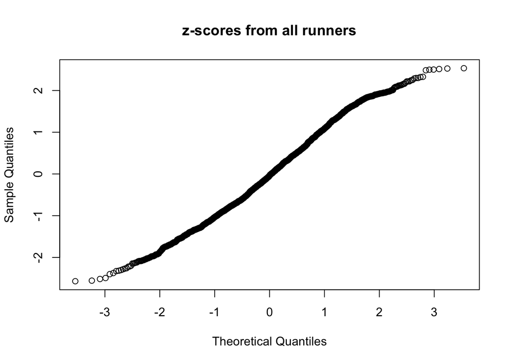

```r
runner_data_standardized = numeric(length(runner_data$Time.Seconds))

for (i in 1:length(runner_data$Time.Seconds)) {
  runner_data_standardized[i] = (runner_data$Time.Seconds[i] - xbarT) / sT
}

qqnorm(runner_data_standardized, main="z-scores from all runners")
```

```r
#Assuming female is 1, male is 2
female_runners = runner_data[runner_data$Gender == 1,]
male_runners = runner_data[runner_data$Gender == 2,]

female_xbarT = mean(female_runners$Time.Seconds)
female_sT = sd(female_runners$Time.Seconds)
female_xbarT
```

```
## [1] 16477.64
```

```r
female_sT
```

```
## [1] 2247.552
```